# act_report

## Act_report

### WeRateDogs Project by Kaittkee Sarmalkar

Watch out people...Puppos are coming for you! As a dog lover all I can say is that all dogs are cute. Working on this project has been a lot of fun and this is my dedication to my dear dog cherry, the only pet I ever had.

WeRateDogs downloaded their Twitter archive and sent it to Udacity via email exclusively for you to use in this project. This archive contains basic tweet data (tweet ID, timestamp, text, etc.) for all 5000+ of their tweets as they stood on August 1, 2017.

[figure not shown]

The data provided had a lot of quality issues which had to be fixed before analyzing the data. The column names had to be updated, the datatypes in the columns had to be fixed, columns that had a lot of blank data and could not be used for the analysis had to be deleted and 💥 the data was ready to be analyzed!

The analysis part was the part where the actual fun started. I wanted to see if there was a favorite 🐶 stage andddd I found my winner. Ladies and gentlemen, our sweet "puppo" was the winner.

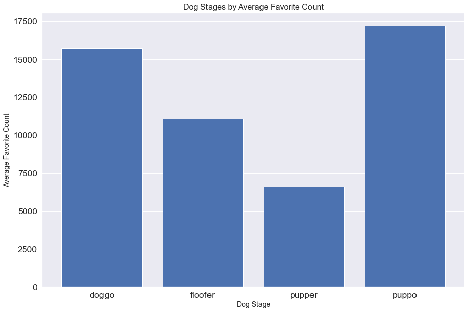

Well my curious brain wanted to test this more so I went a step further. I tested to see if a dog stage receive better ratings compared to other dog stages and our over achiever puppo was the winner here too.

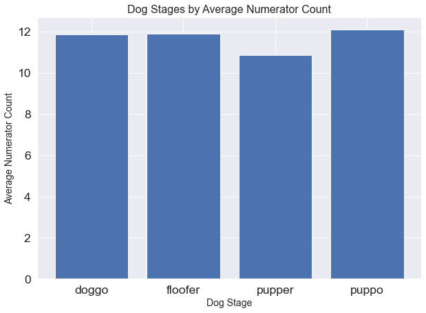

If there was a favorite dog stage there must a a favorite breed too. We all have our biases after all. 🧐 and I indeed found that there were breeds that were people's favorite. Golden retriever was a clear winner here since it received higher retweets.

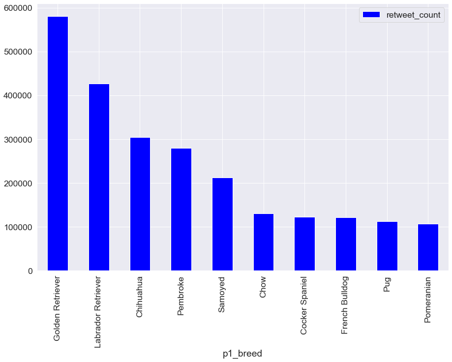

Like all good things come to an end so did my analysis, but before I could do that I had to answer one more burning question. That's how the fancy term correlation came into picture. Were the retweets_count, favorite_count and the rating_numerator correlated. Although retweet_count and favorite_count were strongly correlated the rating_numerator was not.

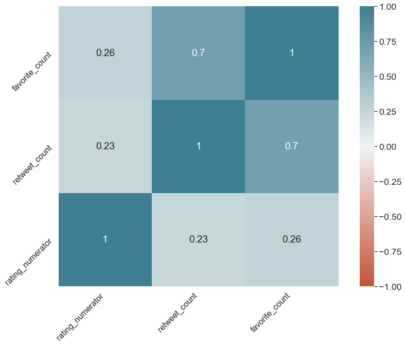

Hope you enjoyed reading this! And hopefully my cute 🐕 is looking down at me from heaven today and smiling. This one is for you cherry! I miss you dearly!